# Tugas Praktikum 5

Bilal Muhammad Thalib (G1401231093)

2025-10-03

# Library

```r
library(ggplot2)
library(tsibble)
library(tseries)
library(MASS)
library(readxl)
```

# Data

```r
# Baca file Excel
df <- read_excel("C:/Documents/Bilal/Kuliah/MPDW/Page Loads.xlsx")

# Ambil baris 401 - 500
df_subset <- df[401:500, ]
head(df_subset)
```

```
## # A tibble: 6 × 2
##   Date                Page.Loads
##   <dttm>                   <dbl>
## 1 2015-10-19 00:00:00       5516
## 2 2015-10-20 00:00:00       5572
## 3 2015-10-21 00:00:00       5243
## 4 2015-10-22 00:00:00       5133
## 5 2015-10-23 00:00:00       4084
## 6 2015-10-24 00:00:00       2739
```

```r
# Ubah ke Time Series
clicks <- ts(df_subset$Page.Loads)
```

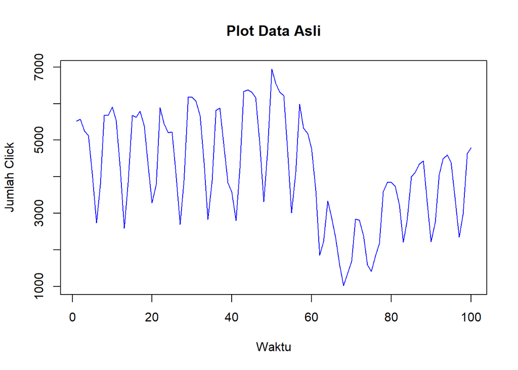

```r
# Periksa Grafik TS
plot(clicks, main="Plot Data Asli", col="blue", ylab="Jumlah Click", xlab="Waktu")
```

Berdasarkan Plot Data diatas terlihat bahwa terdapat fluktuasi naik-turun yang terlihat cukup berbeda pada rentang waktu tertentu, seperti ada siklus ‘Seasonality’. Oleh karena itu, dapat diindikasikan terlebih dahulu bahwa data belum stasioner.

# Pengecekan Stasioneritas

## Uji ACF dan PACF untuk pola autokorelasi

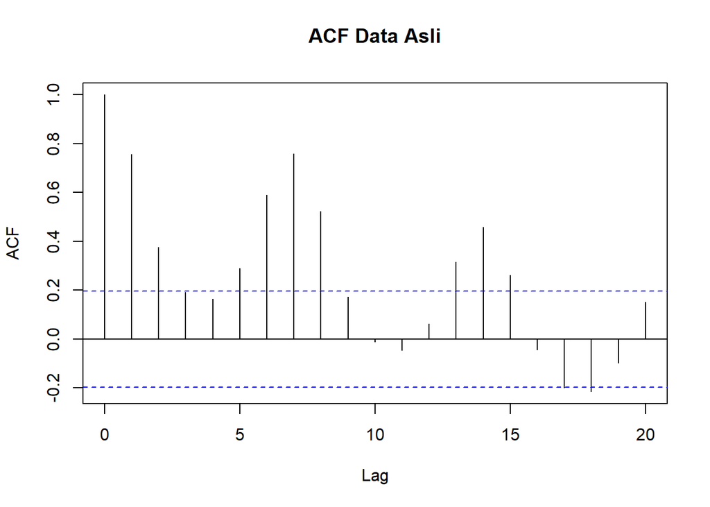

```r
acf(clicks, main="ACF Data Asli")
```

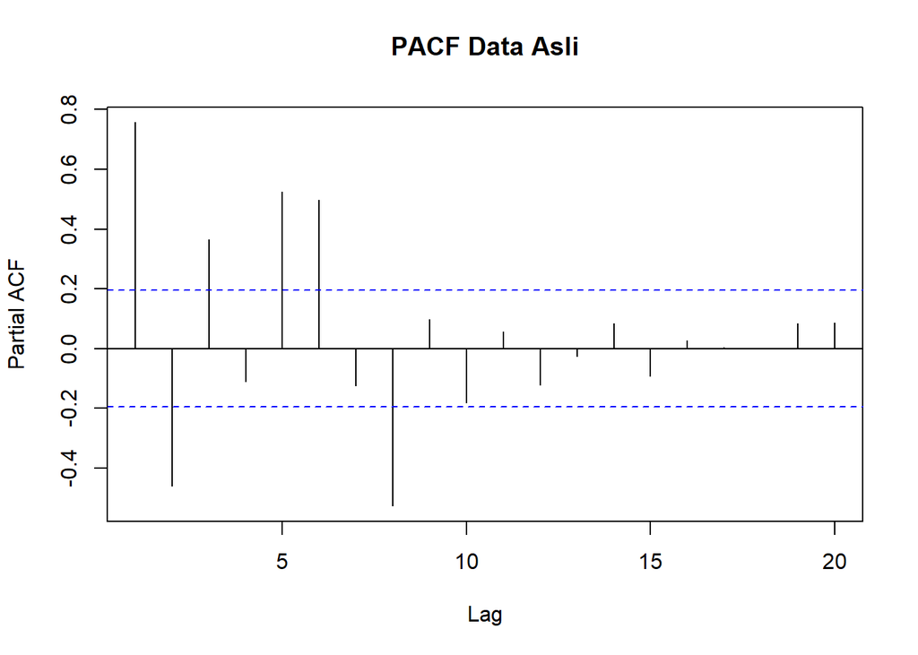

```r
pacf(clicks, main="PACF Data Asli")
```

Berdasarkan plot ACF diatas, data belum stasioner karena masih ada autokorelasi yang kuat di banyak lag dan menurun secara perlahan (Slow Decay), bukan langsung memotong (cut-off). Oleh karena itu, diperlukan differencing terhadap data yang digunakan.

## Differencing

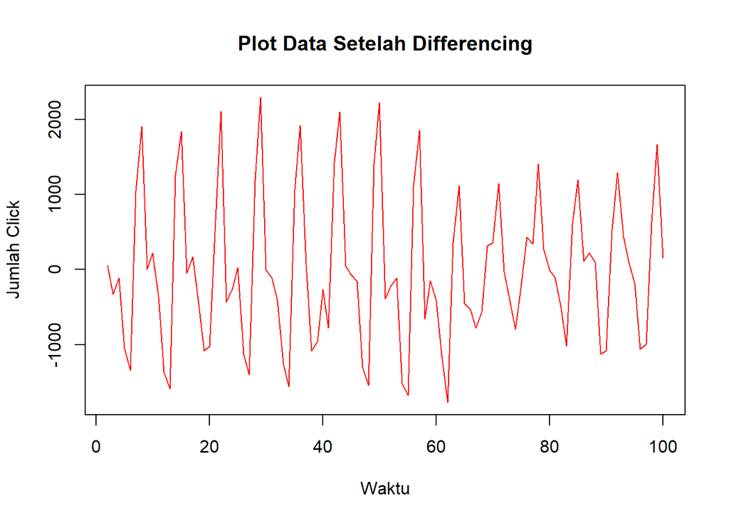

```r
clicks_diff <- diff(clicks)
plot(clicks_diff, main="Plot Data Setelah Differencing", col="red", ylab="Jumlah Click", xlab="Waktu")
```

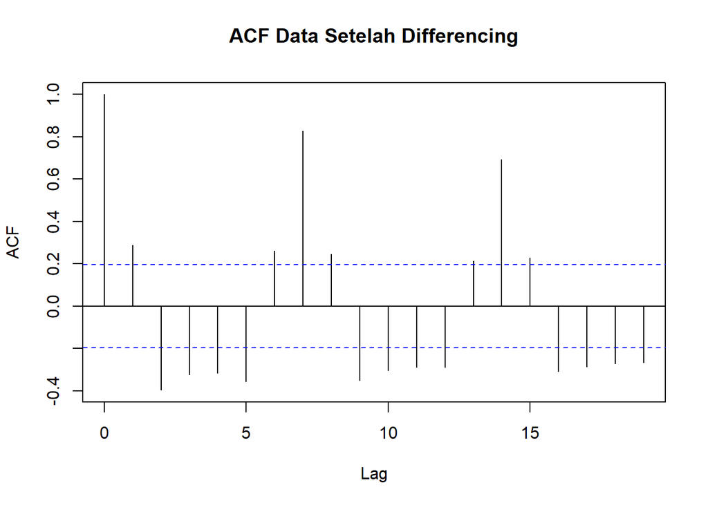

```r
acf(clicks_diff, main="ACF Data Setelah Differencing")
```

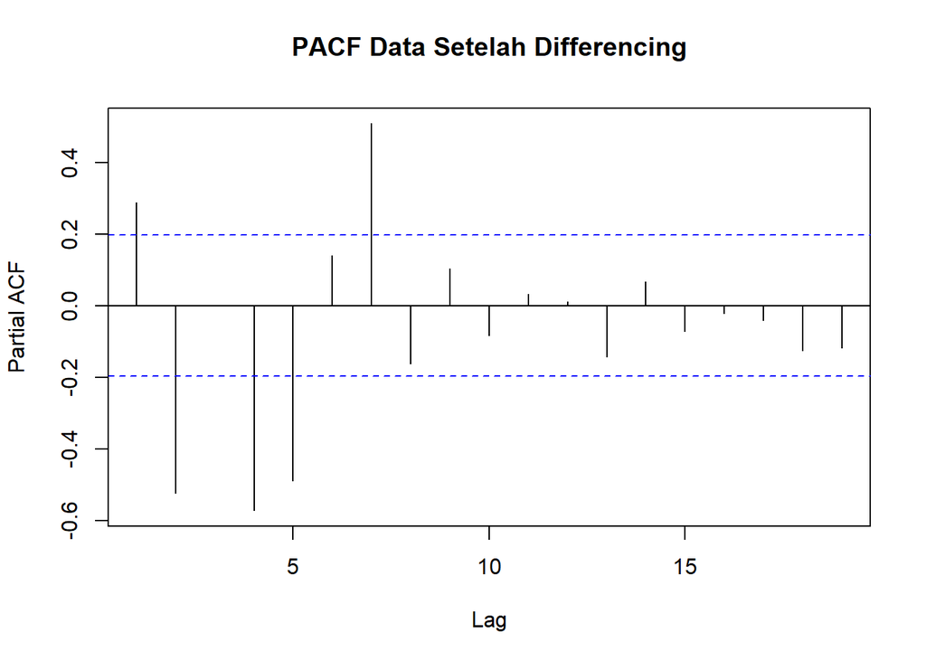

```r
pacf(clicks_diff, main="PACF Data Setelah Differencing")
```

## Uji ADF

```r
adf.test(clicks)
```

```
##
##  Augmented Dickey-Fuller Test
##
## data:  clicks
## Dickey-Fuller = -2.1199, Lag order = 4, p-value = 0.527
## alternative hypothesis: stationary
```

$H_0$ : Data tidak stasioner dalam rataan

$H_1$ : Data stasioner dalam rataan

Karena p-value > 0.05, maka gagal menolak H0 yang artinya terdapat ketidakstasioneran pada data.

```r
adf.test(clicks_diff)
```

```
##
##  Augmented Dickey-Fuller Test
##
## data:  clicks_diff
## Dickey-Fuller = -13.224, Lag order = 4, p-value = 0.01
## alternative hypothesis: stationary
```

## Plot Box-Cox

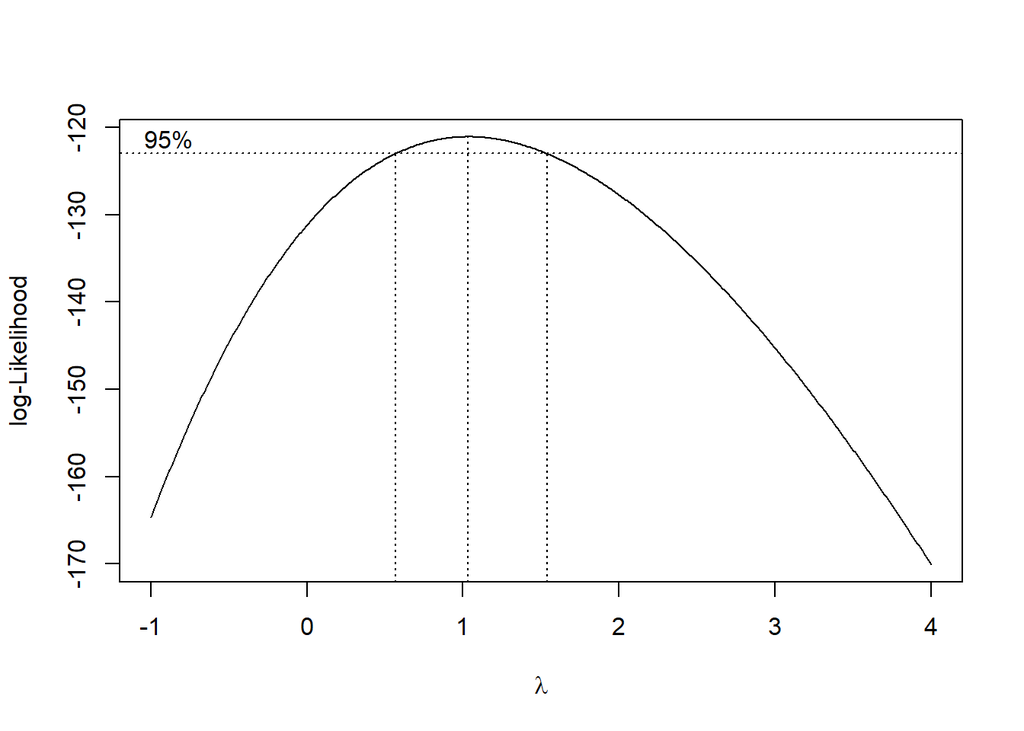

```r
index = seq(401:500)

# Box-Cox
b <- boxcox(
  clicks ~ index,
  lambda = seq(-1, 4, by = 0.01)
)
```

```r
#Nilai Rounded Lambda
lambda = b$x[which.max(b$y)]
lambda
```

```
## [1] 1.03
```

```r
# Selang kepercayaan 95% untuk lambda
ci_lambda <- b$x[b$y > max(b$y) - 0.5 * qchisq(0.95, 1)]

# Batas bawah dan batas atas
ci_lower <- min(ci_lambda)
ci_upper <- max(ci_lambda)

c(Batas_Bawah = ci_lower, Batas_Atas = ci_upper)
```

```
## Batas_Bawah  Batas_Atas
##        0.57        1.53
```

# Partisi Data

## Train Data

```r
train_size = floor(0.8 * length(clicks))
train_data = clicks[1:train_size]
print(train_data)
```

```
##  [1] 5516 5572 5243 5133 4084 2739 3781 5684 5687 5906 5541 4171 2586 3838 5675
## [16] 5624 5794 5389 4305 3281 3790 5894 5461 5206 5228 4097 2694 3893 6185 6178
## [31] 6067 5656 4398 2836 3896 5814 5879 4800 3838 3576 2799 4228 6331 6380 6314
## [46] 6160 4859 3317 4715 6940 6551 6327 6212 4687 3014 4132 5989 5331 5183 4769
## [61] 3627 1857 2221 3335 2883 2353 1578 1017 1334 1690 2838 2815 2382 1587 1411
## [76] 1838 2180 3587 3855 3840
```

```r
mean(train_data)
```

```
## [1] 4292.512
```

```r
var(train_data)
```

```
## [1] 2380989
```

### Plot Time Series Train Data

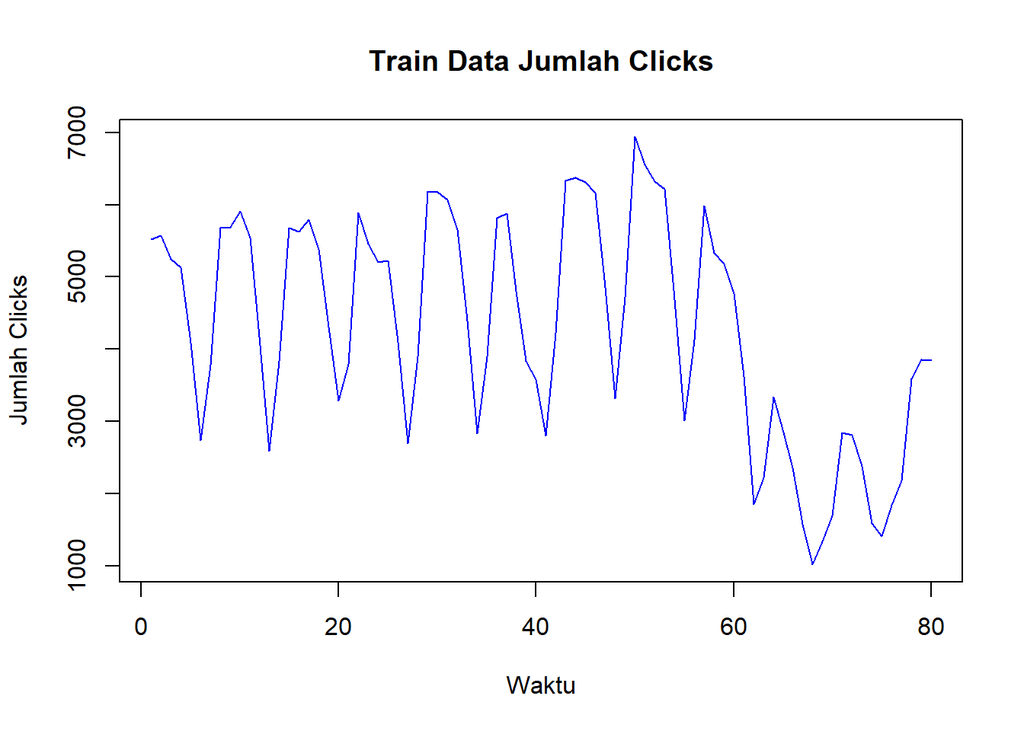

```r
plot.ts(train_data, main = "Train Data Jumlah Clicks", ylab = "Jumlah Clicks", xlab = "Waktu", col = "blue")
```

### ACF Train Data

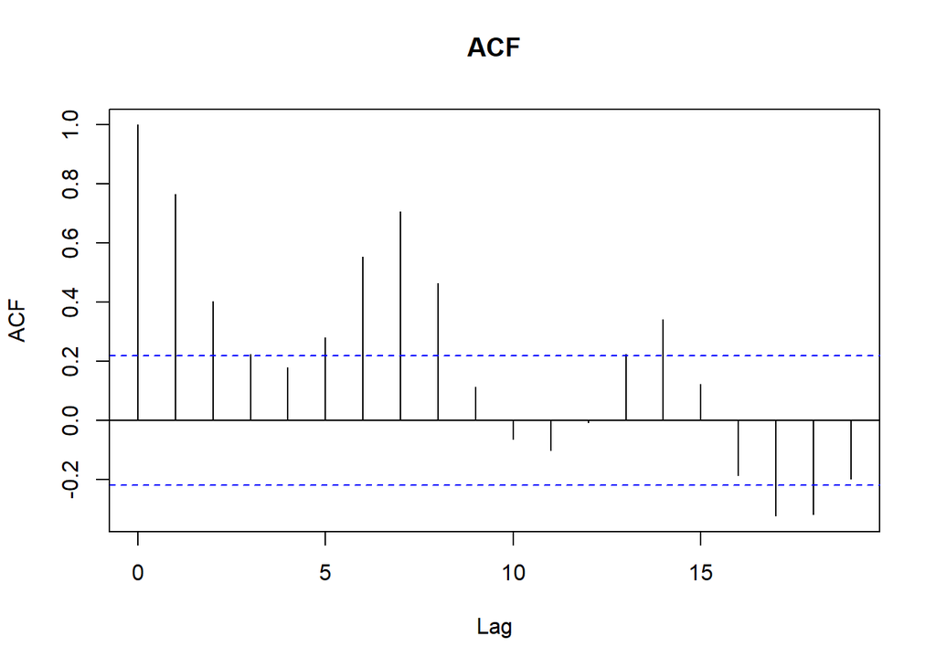

```r
acf(train_data, main = "ACF")
```

Dari plot di atas menunjukkan bahwa data tidak stasioner karena nilai ACF menurun secara perlahan.

### Uji ADF Train Data

```r
adf.test(train_data)
```

```
##
##  Augmented Dickey-Fuller Test
##
## data:  train_data
## Dickey-Fuller = -2.0891, Lag order = 4, p-value = 0.5392
## alternative hypothesis: stationary
```

$H_0$ : Data tidak stasioner dalam rataan $H_1$ : Data stasioner dalam rataan

Karena p-value > 0.05, maka gagal menolak H0 yang artinya terdapat ketidakstasioneran pada data.

### Box-Cox Train Data

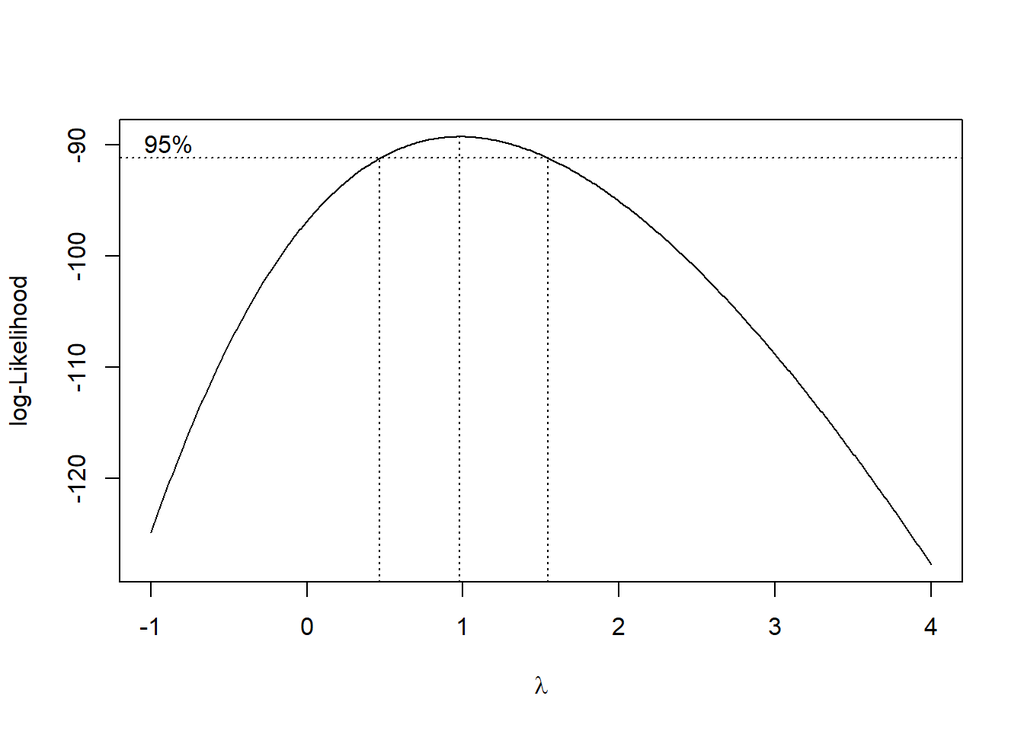

```r
idx = seq(401:480)

# Box-Cox
b <- boxcox(
  train_data ~ idx,
  lambda = seq(-1, 4, by = 0.01)
)
```

```r
#Nilai Rounded Lambda
lambda = b$x[which.max(b$y)]
lambda
```

```
## [1] 0.98
```

```r
# Selang kepercayaan 95% untuk lambda
ci_lambda <- b$x[b$y > max(b$y) - 0.5 * qchisq(0.95, 1)]

# Batas bawah dan batas atas
ci_lower <- min(ci_lambda)
ci_upper <- max(ci_lambda)

c(Batas_Bawah = ci_lower, Batas_Atas = ci_upper)
```

```
## Batas_Bawah  Batas_Atas
##        0.47        1.54
```

Plot di atas menunjukkan nilai *rounded value* ($\lambda$) optimum sebesar **0.98** dan pada selang kepercayaan 95% nilai memiliki batas bawah **0.47** dan batas atas **1.54**. Selang tersebut memuat nilai satu sehingga dapat dikatakan bahwa data stasioner dalam ragam.

### Test Data

```r
test_data = clicks[(train_size + 1):length(clicks)]
print(test_data)
```

```
##  [1] 3735 3223 2207 2814 4007 4119 4338 4432 3306 2223 2757 4047 4489 4588 4398
## [16] 3340 2344 2973 4638 4791
```

```r
mean(test_data)
```

```
## [1] 3638.45
```

```r
var(test_data)
```

```
## [1] 746915.3
```

### Plot Time Series Test Data

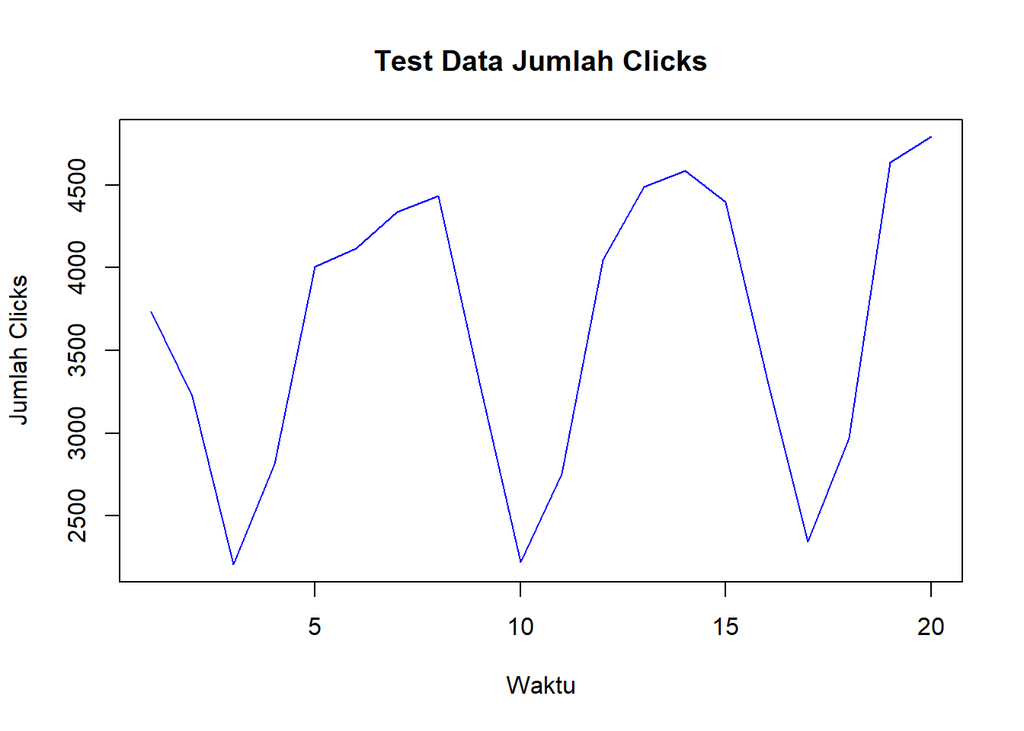

```r
ts.plot(test_data, main = "Test Data Jumlah Clicks", ylab = "Jumlah Clicks", xlab = "Waktu", col = "blue")
```

### ACF Test Data

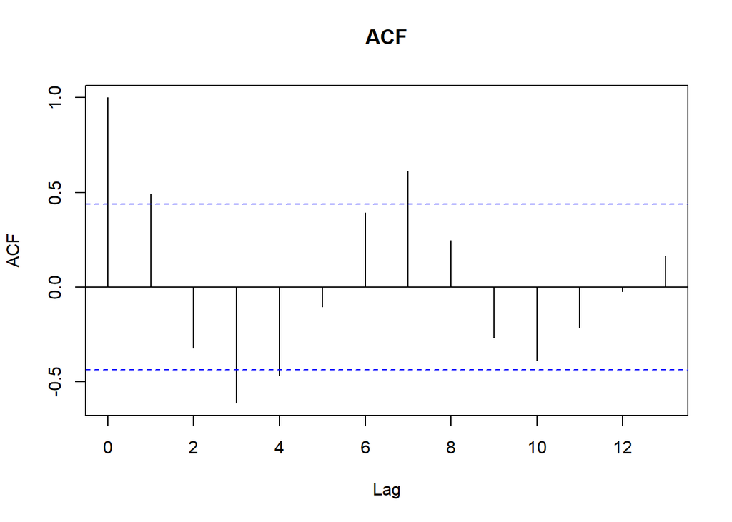

```r
acf(test_data, main = "ACF")
```

### Uji ADF Test Data

```r
adf.test(test_data)
```

```
##
##  Augmented Dickey-Fuller Test
##
## data:  test_data
## Dickey-Fuller = -3.3162, Lag order = 2, p-value = 0.08941
## alternative hypothesis: stationary
```

$H_0$ : Data tidak stasioner dalam rataan $H_1$ : Data stasioner dalam rataan

Karena p-value > 0.05, maka gagal menolak H0 yang artinya terdapat ketidakstasioneran pada data.

### Box-Cox Test Data

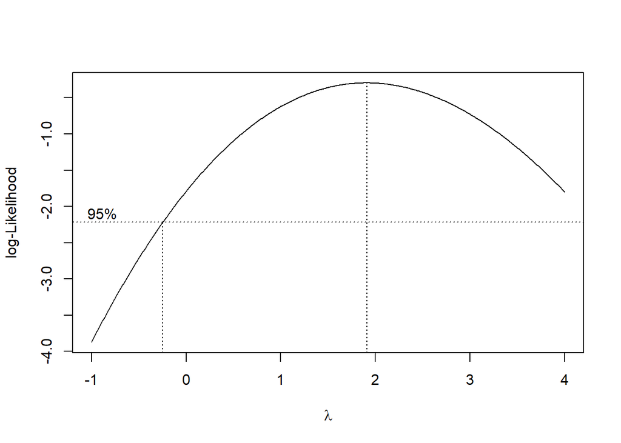

```r
idy = seq(481:500)

# Box-Cox
b <- boxcox(
  test_data ~ idy,
  lambda = seq(-1, 4, by = 0.01)
)
```

```r
#Nilai Rounded Lambda
lambda = b$x[which.max(b$y)]
lambda
```

```
## [1] 1.91
```

```r
# Selang kepercayaan 95% untuk lambda
ci_lambda <- b$x[b$y > max(b$y) - 0.5 * qchisq(0.95, 1)]

# Batas bawah dan batas atas
ci_lower <- min(ci_lambda)
ci_upper <- max(ci_lambda)

c(Batas_Bawah = ci_lower, Batas_Atas = ci_upper)
```

```
## Batas_Bawah  Batas_Atas
##       -0.24        4.00
```

Plot di atas menunjukkan nilai *rounded value* ($\lambda$) optimum sebesar **1.91** dan pada selang kepercayaan 95% nilai memiliki batas bawah **-0.24** dan batas atas **4.00**. Selang tersebut memuat nilai satu sehingga dapat dikatakan bahwa data stasioner dalam ragam.